# **Part A: Convolutional Neural Network**

### Efficient Net (Transfer Learning)

Below is how efficient net looks like

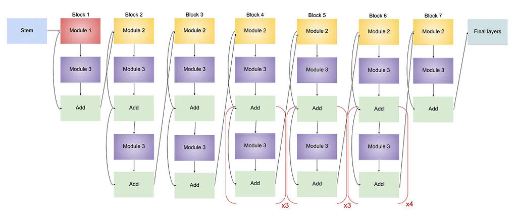

Efficient Net:

- Network is fine-tuned for obtaining maximum accuracy but is also penalised if the network is very computationally heavy
- Also penalised for slow inference time when the network takes a lot of time to make predictions. The architecture uses a mobile inverted bottleneck convolution similar to MobileNet V2 but is much larger due to the increase in FLOP
- This baseline model is scaled up to obtain the family of EfficientNet

**My Implementation**

```python
def convert(x):
    return tf.tile(x, [1, 1, 1, 3])

input_layer = Input(shape=(31, 31, 1))
replicated_channels = Lambda(convert)(input_layer)

efficient_net = EfficientNetB3(
    weights='imagenet',
    include_top=False,
    pooling='max'
)(replicated_channels)

x = Dense(units=120, activation='relu')(efficient_net)
x = Dense(units=120, activation='relu')(x)
output = Dense(15, activation='softmax')(x)


efficient = Model(inputs=input_layer, outputs=output)
efficient.compile(optimizer='adam', loss='binary_crossentropy', metrics=['accuracy'])
efficient.summary()
```

```
Model: "model"
_________________________________________________________________
 Layer (type)                Output Shape              Param #
=================================================================
 input_1 (InputLayer)        [(None, 31, 31, 1)]       0

 lambda (Lambda)             (None, 31, 31, 3)         0

 efficientnet-b3 (Functional  (None, 1536)             10783528
 )

 dense (Dense)               (None, 120)               184440

 dense_1 (Dense)             (None, 120)               14520

 dense_2 (Dense)             (None, 15)                1815

=================================================================
Total params: 10,984,303
Trainable params: 10,897,007
Non-trainable params: 87,296
_________________________________________________________________
```

#### Running the model

```python
results_efficient, fig_efficient = evaluator.model_evaluate( train_ds, val_ds , efficient, base_hparams)
```

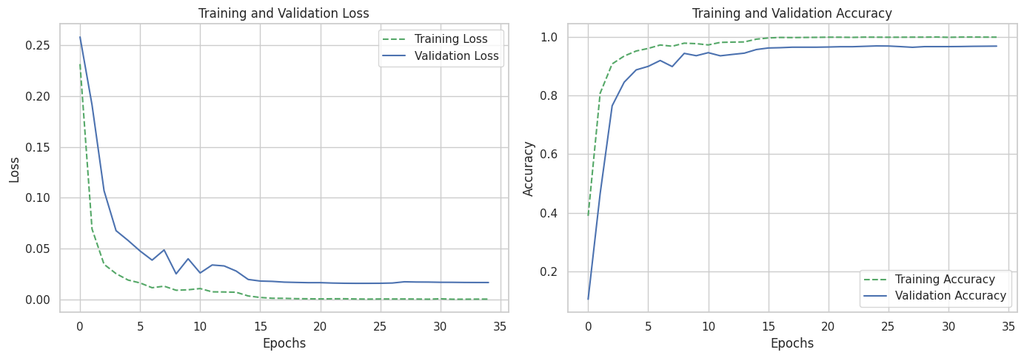

```python
fig_efficient()
```

```python
pd.Series(results_efficient)
```

```
Model Name       model
Epochs              35
Batch Size         128
Train Loss    0.000518
Test Loss     0.016012
Train Acc     0.998782
Test Acc         0.969
dtype: object
```

*Things Observed*

- Training and Validation loss  
 - For the training loss, it starts relatively high and drops quickly and continues to decrease steadily as the epochs increases  
 - For the validation loss, similar patterns occur with the epoch increasing with really minor spikes  
- Training and Validation accuracy  
 - For the training accuracy, it increases sharply at the beginning and continues to increase gradually, indicates effective lerarning  
 - For the validation accuracy, similar pattern is seen but with a similar accuracy and minor spikes

#### Evaluation on test set

- This is to check for overfitting
- And also how the model performs with respect to each classes

```python
cls_df_efficient = evaluation_test(efficient, X_test_small, y_test_small, labels_dict)
cls_df_efficient
```

```
Accuracy: 0.9713333333333334
```

|  | precision | recall | f1-score | support |
| --- | --- | --- | --- | --- |
| Cabbage | 0.954315 | 0.940000 | 0.947103 | 200.000000 |
| Broccoli | 0.937500 | 0.975000 | 0.955882 | 200.000000 |
| Pumpkin | 0.989418 | 0.935000 | 0.961440 | 200.000000 |
| Cauliflower | 0.964824 | 0.960000 | 0.962406 | 200.000000 |
| Tomato | 0.946860 | 0.980000 | 0.963145 | 200.000000 |
| Brinjal | 0.942857 | 0.990000 | 0.965854 | 200.000000 |
| Potato | 0.979487 | 0.955000 | 0.967089 | 200.000000 |
| Bitter_Gourd | 0.974619 | 0.960000 | 0.967254 | 200.000000 |
| Bean | 0.969849 | 0.965000 | 0.967419 | 200.000000 |
| macro avg | 0.971651 | 0.971333 | 0.971328 | 3000.000000 |
| weighted avg | 0.971651 | 0.971333 | 0.971328 | 3000.000000 |
| accuracy | 0.971333 | 0.971333 | 0.971333 | 0.971333 |
| Radish | 0.984772 | 0.970000 | 0.977330 | 200.000000 |
| Carrot | 0.979899 | 0.975000 | 0.977444 | 200.000000 |
| Papaya | 0.984848 | 0.975000 | 0.979899 | 200.000000 |
| Cucumber | 0.975490 | 0.995000 | 0.985149 | 200.000000 |
| Capsicum | 0.995000 | 0.995000 | 0.995000 | 200.000000 |
| Bottle_Gourd | 0.995025 | 1.000000 | 0.997506 | 200.000000 |

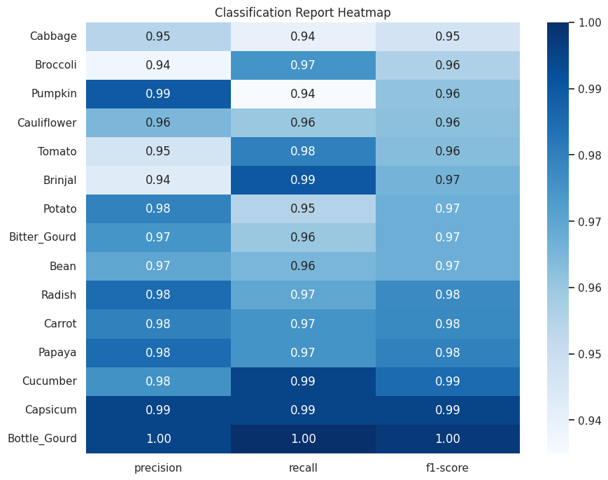

```python
plot_classification_heatmap(cls_df_efficient)
```

*Things Observed*

#### Cohen Kappa Coefficient

```python
y_pred = efficient.predict(X_test_small)
y_pred_classes = np.argmax(y_pred, axis=1)
kappa_efficient = cohen_kappa_score(y_test_small, y_pred_classes)
print("Cohen’s Kappa Score:", kappa_efficient)
```

```
Cohen’s Kappa Score: 0.9692857142857143
```

Adding results to dataframe

*Things Observed*

Adding results to dataframe

```python
results_efficient['Model Name'] = 'EfficientNet (Transfer Learning)'
results_efficient['Kappa'] = kappa_efficient
overall = pd.concat([overall, pd.DataFrame([results_efficient])], ignore_index=True)
overall
```

|  | Model Name | Epochs | Batch Size | Train Loss | Test Loss | Train Acc | Test Acc | Kappa | Comments |
| --- | --- | --- | --- | --- | --- | --- | --- | --- | --- |
| 0 | Baseline_Dense_Model | 42 | 128 | 0.914943 | 1.486889 | 0.715884 | 0.554000 | 0.527857 | NaN |
| 1 | CNN_Baseline | 52 | 128 | 0.074410 | 0.261325 | 0.976961 | 0.927333 | 0.924643 | NaN |
| 2 | CNN_Baseline2 | 44 | 128 | 0.025112 | 0.111673 | 0.998006 | 0.968000 | 0.968571 | NaN |
| 3 | VGGNet_Baseline | 52 | 128 | 0.164630 | 0.273673 | 0.999668 | 0.968333 | 0.962857 | NaN |
| 4 | Resnet50 | 46 | 128 | 3.042697 | 3.611549 | 0.998892 | 0.875667 | 0.866071 | NaN |
| 5 | EfficientNet (Transfer Learning) | 35 | 128 | 0.000518 | 0.016012 | 0.998782 | 0.969000 | 0.969286 | NaN |

```python
overall.sort_values(by='Test Loss', inplace=True)
overall
```

|  | Model Name | Epochs | Batch Size | Train Loss | Test Loss | Train Acc | Test Acc | Kappa | Comments |
| --- | --- | --- | --- | --- | --- | --- | --- | --- | --- |
| 5 | EfficientNet (Transfer Learning) | 35 | 128 | 0.000518 | 0.016012 | 0.998782 | 0.969000 | 0.969286 | NaN |
| 2 | CNN_Baseline2 | 44 | 128 | 0.025112 | 0.111673 | 0.998006 | 0.968000 | 0.968571 | NaN |
| 1 | CNN_Baseline | 52 | 128 | 0.074410 | 0.261325 | 0.976961 | 0.927333 | 0.924643 | NaN |
| 3 | VGGNet_Baseline | 52 | 128 | 0.164630 | 0.273673 | 0.999668 | 0.968333 | 0.962857 | NaN |
| 0 | Baseline_Dense_Model | 42 | 128 | 0.914943 | 1.486889 | 0.715884 | 0.554000 | 0.527857 | NaN |
| 4 | Resnet50 | 46 | 128 | 3.042697 | 3.611549 | 0.998892 | 0.875667 | 0.866071 | NaN |

*Things Observed*

- Overall, I will use,Vgg Net Baseline and the 2 cnn baseline (Focused) in the next few steps

### Continue....

```python
overall.to_csv('BaselineModel (31x31).csv')
```